## Results (SIMULATED)

> SIMULATED DATA AND RESULTS FROM PREANALYSIS PLAN WILL BE MOVED TO AN APPENDIX

### Simulated Data

To illustrate my planned analysis, I simulate data for each variable described above.

**Dependent variable:** *Coalition success* is drawn from a descrete distribution {-1, -.5, 0, .5, 1}.

Table @ref(tab:data-sim) shows ten rows of simulated data.

```r
coalition_success <- sample(x = c(-1, -.5, 0, .5, 1), 1000, prob = c(0.1, 0.3, .1, 0.4, 0.1), replace = T)

d = tibble(rule_id = c(1:1000, rep(1001:1500, 2)),
           coalition_id = sample(1:2000),
           coalitions  = c(rep(1, 1000), rep(2, 1000)),
           coalition_unopposed = c(rep(0, 1000), rep(1, 1000)),
           coalition_success = c(coalition_success, sort(coalition_success)),
           coalition_size = rtnorm(1000, mean = 5, sd= 10, lower = 1) %>% rep(2) %>% round(),
           coalition_business = sample(x = c(0,1), 2000, replace = T, prob = c(0.3, .7)),
           comment_length = round(rpois(2000, 10)/85 *100, 1),
           comments= c(rtnorm(1000, mean = 10000, sd = 100000, lower = 100), rep(1, 1000)) %>% sample() %>% round() ,
           cong_support = c(rtnorm(1000, mean = 1, sd = 5, lower = 0), rep(0, 1000)) %>% sample() %>% round() )

d %>% sample_n(10) %>% dplyr::select(rule_id, coalition_id, everything()) %>% knitr::kable(caption = "Simulated data")
```

Simulated data

| rule_id | coalition_id | coalitions | coalition_unopposed | coalition_success | coalition_size | coalition_business | comment_length | comments | cong_support |
| --- | --- | --- | --- | --- | --- | --- | --- | --- | --- |
| 1121 | 1006 | 2 | 1 | 0.5 | 3 | 1 | 2.4 | 1 | 0 |
| 705 | 1440 | 1 | 0 | -1.0 | 3 | 0 | 10.6 | 115956 | 3 |
| 1496 | 1206 | 2 | 1 | 1.0 | 22 | 1 | 14.1 | 56763 | 0 |
| 1409 | 1467 | 2 | 1 | 0.0 | 10 | 1 | 15.3 | 6237 | 5 |
| 1142 | 1995 | 2 | 1 | -0.5 | 14 | 1 | 11.8 | 89838 | 0 |
| 620 | 1737 | 1 | 0 | 1.0 | 12 | 1 | 10.6 | 1 | 11 |
| 1260 | 756 | 2 | 1 | 0.5 | 4 | 0 | 10.6 | 89287 | 0 |
| 583 | 739 | 1 | 0 | -1.0 | 19 | 1 | 10.6 | 83950 | 0 |
| 732 | 334 | 1 | 0 | 0.5 | 2 | 0 | 9.4 | 21786 | 3 |
| 1473 | 1191 | 2 | 1 | 0.5 | 1 | 1 | 18.8 | 1 | 7 |

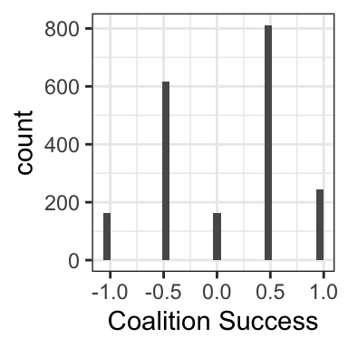

```r
ggplot(d, aes(x = coalition_success)) + geom_histogram()+ labs(x = "Coalition Success")
```

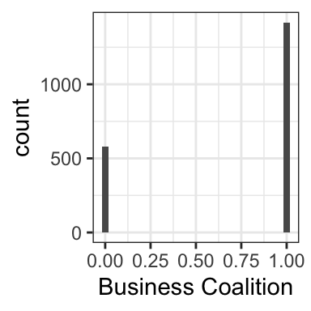

```r
ggplot(d, aes(x = coalition_business)) + geom_histogram()+ labs(x = "Business Coalition")
```

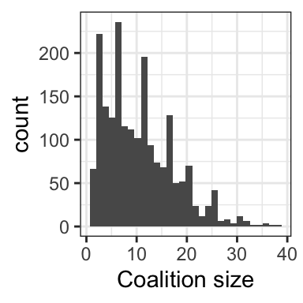

```r
ggplot(d, aes(x = coalition_size)) + geom_histogram()+ labs(x = "Coalition size")
```

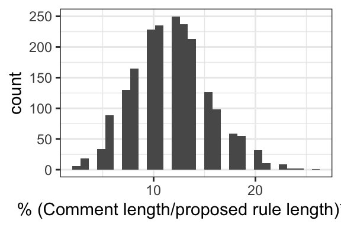

```r
ggplot(d, aes( x= comment_length)) + geom_histogram()+ labs(x = "% (Comment length/proposed rule length)*100")
```

[figure not shown]

```r
ggplot(d, aes( x= comments)) + geom_histogram() + labs(x = "Log(comments)")
```

### Simulated Results

Unsurprisingly this model yields no significant results (Figure @ref(fig:model-success-plot-sim), Table @ref(tab:mediation-sim)). With lobbying success as the dependent variable, the coefficient on the main variable of interest would be interpreted as a $\beta_{logmasscomments}$ increase in the five-point influence scale of lobbying success for each one-unit increase in the logged number of comments.

```r
m <- lm(coalition_success ~
          log(comments) +
          comment_length +
          coalition_business +
          coalition_size +
          coalition_unopposed,
        data = d)
```

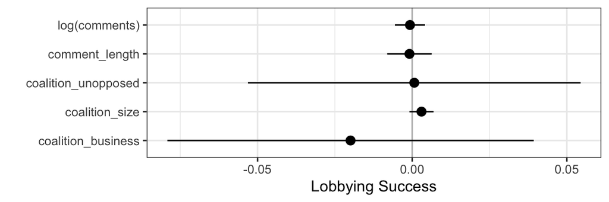

OLS model of coalition lobbying sucess with simulated data

```r
m %>%
  tidy(conf.int = TRUE) %>%
  filter(term != "(Intercept)") %>%
  ggplot() +
  geom_hline(yintercept = 0, color = "grey") +
  aes(x = term,
      y = estimate,
      ymin = conf.low,
      ymax = conf.high) +
  geom_pointrange( )  +
  coord_flip() +
  labs(y = "Lobbying Success",
       x = "")
```

To assess the extent to which congressional support mediates the influence of public pressure campaigns on rulemaking, I estimate the average conditional marginal effect (ACME, conditional on the number of comments from Members of Congress) and average direct effect (ADE) of mass comments using mediation analysis. Model 3 in table @ref(tab:mediation-sim) replaces the dependent varible (lobbying success) with the mediator variable (the number of supportive members of Congress).

```r
library(mediation)

# model predicting mediator
model.m <- lm(cong_support ~  log(comments) + comment_length + coalition_business+  coalition_size + coalition_unopposed, data = d)

# model predicting DV
model.y <- lm(coalition_success ~ log(comments) + cong_support + comment_length + coalition_business+  coalition_size + coalition_unopposed, data = d)

med.cont <- mediate(model.m, model.y, sims=1000, treat = "log(comments)",
mediator = "cong_support")

# summary(med.cont)

library(modelsummary)
models <- list(
  "1" = m,
  "2" = model.y,
  "3"  =  model.m
)

rows <- tibble(
  term = c("Dependent Variable"),
  `1` = c("Lobbying Success"),
  `2` =c("Lobbying Success"),
  `3`  = c("Members of Congress in Coalition")
)

# #broom::tidy(m_PR)
# cm = c("ej_commentTRUE" = "EJ Comment",
#        "log(comments + 1)" = "Log(Comments+1)",
#        "ej_comments_unique" = "Unique EJ Comments",
#        "ej_commentTRUE:log(comments + 1)" = "EJ Comment*Log(Comments+1)")

attr(rows, 'position') <- c(0)

# paper table
modelsummary::modelsummary( models,
                            title = "Lobbying success and congressional support with simulated data",
                            stars = TRUE,
                            #coef_omit = "president.*|agency.*|Intercept",
                            # coef_map = cm,
                          add_rows = rows,
                          notes = "") %>%
  row_spec(row = 1, bold = T)
```

Lobbying success and congressional support with simulated data

|  | 1 | 2 | 3 |
| --- | --- | --- | --- |
| Dependent Variable | Lobbying Success | Lobbying Success | Members of Congress in Coalition |
| (Intercept) | 0.085 | 0.078 | 2.110*** |
|  | (0.057) | (0.058) | (0.306) |
| log(comments) | −0.001 | −0.001 | 0.025+ |
|  | (0.002) | (0.002) | (0.013) |
| comment_length | −0.001 | −0.001 | 0.001 |
|  | (0.004) | (0.004) | (0.020) |
| coalition_business | −0.020 | −0.021 | 0.160 |
|  | (0.030) | (0.030) | (0.162) |
| coalition_size | 0.003 | 0.003 | −0.008 |
|  | (0.002) | (0.002) | (0.011) |
| coalition_unopposed | 0.001 | 0.001 | −0.108 |
|  | (0.027) | (0.027) | (0.147) |
| cong_support |  | 0.004 |  |
|  |  | (0.004) |  |
| Num.Obs. | 2000 | 2000 | 2000 |
| R2 | 0.001 | 0.002 | 0.003 |
| R2 Adj. | −0.001 | −0.001 | 0.000 |
| AIC | 3723.0 | 3724.2 | 10450.5 |
| BIC | 3762.2 | 3769.0 | 10489.7 |
| Log.Lik. | −1854.476 | −1854.091 | −5218.260 |
| F | 0.578 | 0.610 | 1.109 |

+ p < 0.1, * p < 0.05, ** p < 0.01, *** p < 0.001

The average effect of the logged number of comments, conditional on letters from members of congress (the ACME) is 0, with a p value of 0.41.

The average direct effect (ADE) of the logged number of comments on lobbying success is 0, with a p value of 0.73

The Total Effect of a one-unit increase in the logged number of comments is 0, with a p value of 0.77. -0.01 of this is mediated through mobilizing congressional attention (p-value = 0.85).